# Geometry

```python
%matplotlib inline
import math
import numpy as np
import matplotlib.pyplot as plt

def createGrid(breadth): #todo: figure out what this kind o fgrid is called
    fig, ax = plt.subplots()
    ax.set_aspect('equal')
    ax.grid(True)

    ax.spines['right'].set_color('none')
    ax.spines['top'].set_color('none')

    ax.xaxis.set_ticks_position('bottom')
    ax.spines['bottom'].set_position(('data',0)) # set position of x spine to x=0

    ax.yaxis.set_ticks_position('left')
    ax.spines['left'].set_position(('data',0))   # set position of y spine to y=0

    ax.set_xlim(-breadth, breadth)
    ax.set_ylim(-breadth, breadth)
```

## Rotating Shapes

*The rotation of a positive angle is left `<`*  
*The rotation of a negative angle is right `>`*

I have to define a shape in code. I think that the *lowest* way to do this would be a collection of verticies or points.

As an example, this should draw some kind of triangle

`[ [2,-7], [7,-7], [2, 3] ]`

I can write a function R(**numpy.array** shape, **degreesToRotate** theta)

rotation anchor (or center) is assumed to be 0, 0

$$ x = cos(theta) * (px-cx) - sin(theta) * (py-cy) + cx $$$$ y = sin(theta) * (px-cx) + cos(theta) * (py-cy) + cy $$

**func R** will only work if I can unpack the *numpy.array* correctly. The shape `[ [2,-7], [7,-7], [2, 3] ]` unpacks into *3* args. I need it to unpack into *2* args, where each arg is a set of points in the same dimension.

Fortunately *numpy* has an easy way to reshape/transform the array.

**numpy.array.reshape** did **NOT** produce the correct set.  
| 2, -7 |  
| 7, -7 |  
| 2, 3 |.reshape(2, -1)

*returns results sequentially in new matrix bounds* **(wrong)**  
| 2, -7, 7 |  
|-7, 2, 3 |

numpy.array.T oddly works...  
| 2, -7 |  
| 7, -7 |  
| 2, 3 |.**T**

*returns results based on dimensions* **(correct)**  
| 2, 7, 2 |  
|-7, -7, 3 |

```python
def R(shape, DegreesToRotate):
    cx, cy = 0, 0
    theta = math.radians(DegreesToRotate)

    Rx = lambda px, py: math.cos(theta) * (px-cx) - math.sin(theta) * (py-cy) + cx
    Ry = lambda px, py: math.sin(theta) * (px-cx) + math.cos(theta) * (py-cy) + cy

    return np.array([Rx(*shape.T), Ry(*shape.T)]).T
```

```
answer [[ 7  2]
 [ 7  7]
 [-3  2]]
computed [[ 7.  2.]
 [ 7.  7.]
 [-3.  2.]]
```

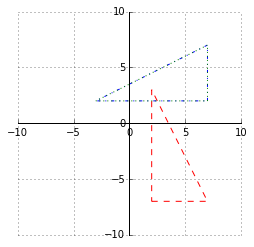

```python
#the original shape
original = np.array([[2,-7], [7,-7], [2, 3]])

rotated = R(original, -270)

answer = np.array([[7, 2], [7, 7], [-3, 2]])

print("answer", answer)
print("computed", rotated)

#boilerplate
createGrid(10)

#just declares the drawable object in memory
triangle = plt.Polygon(original, color='r', fill=0, linestyle='--')
rotatedTri = plt.Polygon(rotated, color='b', fill=0, linestyle='-.')
correctTri = plt.Polygon(answer, color='g', fill=0, linestyle=':')

#actually draw the object(s)
plt.gca().add_patch(triangle)
plt.gca().add_patch(rotatedTri)
plt.gca().add_patch(correctTri)
plt.show()
```